# Reproducible Research Final Project

Erim Celen, Ozgur Polat, Bugra Duman

5/7/2021

## Data Source

**Source:**https://www.football-data.co.uk/data.php

Fulltime and halftime results for up to 22 European league divisions from 25 seasons back to 1993/94. Additional match statistics since 2000/01, including shots on goal, corners, fouls, offsides, bookings, red cards and referees, are also available for the major European football leagues, including the English Premiership and lower divisions, the Socttish Premiersip, German Budnesliga, Spanish la Liga, Italian Serie A and French Championnat.

Historical match betting odds data from up to 10 major online bookmakers are available back to 2000/01. Since 2005/06 average and maximum prices for match betting, total goals and Asian handicap have also been collected from Betbrain. Since 2017/2018, match statistics are available for all 22 divisions.

In this reproducible project you can simply use other datasets in this data source as well. For more information on the dataset please consult the data dictionary below.

## Data Description

All data is in csv format, ready for use within standard spreadsheet applications. Please note that some abbreviations are no longer in use (in particular odds from specific bookmakers no longer used) and refer to data collected in earlier seasons. For a current list of what bookmakers are included in the dataset please visit the link given above.

### Key to results data:

**Div =** League Division  
**Date =** Match Date (dd/mm/yy)  
**Time =** Time of match kick off  
**HomeTeam =** Home Team  
**AwayTeam =** Away Team  
**FTHG and HG =** Full Time Home Team Goals  
**FTAG and AG =** Full Time Away Team Goals  
**FTR and Res =** Full Time Result (H=Home Win, D=Draw, A=Away Win)  
**HTHG =** Half Time Home Team Goals  
**HTAG =** Half Time Away Team Goals  
**HTR =** Half Time Result (H=Home Win, D=Draw, A=Away Win)

### Match Statistics (where available):

Attendance = Crowd Attendance  
Referee = Match Referee  
HS = Home Team Shots  
AS = Away Team Shots  
HST = Home Team Shots on Target  
AST = Away Team Shots on Target  
HHW = Home Team Hit Woodwork  
AHW = Away Team Hit Woodwork  
HC = Home Team Corners  
AC = Away Team Corners  
HF = Home Team Fouls Committed  
AF = Away Team Fouls Committed  
HFKC = Home Team Free Kicks Conceded  
AFKC = Away Team Free Kicks Conceded  
HO = Home Team Offsides  
AO = Away Team Offsides  
HY = Home Team Yellow Cards  
AY = Away Team Yellow Cards  
HR = Home Team Red Cards  
AR = Away Team Red Cards

### Key to 1X2 (match) betting odds data:

B365H = Bet365 home win odds  
B365D = Bet365 draw odds  
B365A = Bet365 away win odds  
BSH = Blue Square home win odds  
BSD = Blue Square draw odds  
BSA = Blue Square away win odds  
BWH = Bet&Win home win odds  
BWD = Bet&Win draw odds  
BWA = Bet&Win away win odds  
GBH = Gamebookers home win odds  
GBD = Gamebookers draw odds  
GBA = Gamebookers away win odds  
IWH = Interwetten home win odds  
IWD = Interwetten draw odds  
IWA = Interwetten away win odds  
LBH = Ladbrokes home win odds  
LBD = Ladbrokes draw odds  
LBA = Ladbrokes away win odds  
PSH and PH = Pinnacle home win odds  
PSD and PD = Pinnacle draw odds  
PSA and PA = Pinnacle away win odds  
SOH = Sporting Odds home win odds  
SOD = Sporting Odds draw odds  
SOA = Sporting Odds away win odds  
SBH = Sportingbet home win odds  
SBD = Sportingbet draw odds  
SBA = Sportingbet away win odds  
SJH = Stan James home win odds  
SJD = Stan James draw odds  
SJA = Stan James away win odds  
SYH = Stanleybet home win odds  
SYD = Stanleybet draw odds  
SYA = Stanleybet away win odds  
VCH = VC Bet home win odds  
VCD = VC Bet draw odds  
VCA = VC Bet away win odds

Data import and imputation of the unused part. Imputated part is also not included in the data description. For full description please refer to: https://www.football-data.co.uk/notes.txt

| Div | Date | Time | HomeTeam | AwayTeam | FTHG | FTAG | FTR | HTHG | HTAG | HTR | Referee | HS | AS | HST | AST | HF | AF | HC | AC | HY | AY | HR | AR | B365H | B365D | B365A | BWH | BWD | BWA | … |
| --- | --- | --- | --- | --- | --- | --- | --- | --- | --- | --- | --- | --- | --- | --- | --- | --- | --- | --- | --- | --- | --- | --- | --- | --- | --- | --- | --- | --- | --- | --- |
| E0 | 09/08/2019 | 20:00:00 | Liverpool | Norwich | 4 | 1 | H | 4 | 0 | H | M Oliver | 15 | 12 | 7 | 5 | 9 | 9 | 11 | 2 | 0 | 2 | 0 | 0 | 1.14 | 10.00 | 19.00 | 1.14 | 8.25 | 18.50 | … |
| E0 | 10/08/2019 | 12:30:00 | West Ham | Man City | 0 | 5 | A | 0 | 1 | A | M Dean | 5 | 14 | 3 | 9 | 6 | 13 | 1 | 1 | 2 | 2 | 0 | 0 | 12.00 | 6.50 | 1.22 | 11.50 | 5.75 | 1.26 | … |
| E0 | 10/08/2019 | 15:00:00 | Bournemouth | Sheffield United | 1 | 1 | D | 0 | 0 | D | K Friend | 13 | 8 | 3 | 3 | 10 | 19 | 3 | 4 | 2 | 1 | 0 | 0 | 1.95 | 3.60 | 3.60 | 1.95 | 3.60 | 3.90 | … |
| E0 | 10/08/2019 | 15:00:00 | Burnley | Southampton | 3 | 0 | H | 0 | 0 | D | G Scott | 10 | 11 | 4 | 3 | 6 | 12 | 2 | 7 | 0 | 0 | 0 | 0 | 2.62 | 3.20 | 2.75 | 2.65 | 3.20 | 2.75 | … |
| E0 | 10/08/2019 | 15:00:00 | Crystal Palace | Everton | 0 | 0 | D | 0 | 0 | D | J Moss | 6 | 10 | 2 | 3 | 16 | 14 | 6 | 2 | 2 | 1 | 0 | 1 | 3.00 | 3.25 | 2.37 | 3.20 | 3.20 | 2.35 | … |
| E0 | 10/08/2019 | 15:00:00 | Watford | Brighton | 0 | 3 | A | 0 | 1 | A | C Pawson | 11 | 5 | 3 | 3 | 15 | 11 | 5 | 2 | 0 | 1 | 0 | 0 | 1.90 | 3.40 | 4.00 | 1.90 | 3.40 | 4.33 | … |
| E0 | 10/08/2019 | 17:30:00 | Tottenham | Aston Villa | 3 | 1 | H | 0 | 1 | A | C Kavanagh | 31 | 7 | 7 | 4 | 13 | 9 | 14 | 0 | 1 | 0 | 0 | 0 | 1.30 | 5.25 | 10.00 | 1.30 | 5.50 | 10.00 | … |
| E0 | 11/08/2019 | 14:00:00 | Leicester | Wolves | 0 | 0 | D | 0 | 0 | D | A Marriner | 15 | 8 | 1 | 2 | 3 | 13 | 12 | 3 | 0 | 2 | 0 | 0 | 2.20 | 3.20 | 3.40 | 2.25 | 3.30 | 3.30 | … |
| E0 | 11/08/2019 | 14:00:00 | Newcastle | Arsenal | 0 | 1 | A | 0 | 0 | D | M Atkinson | 9 | 8 | 2 | 2 | 12 | 7 | 5 | 3 | 1 | 3 | 0 | 0 | 4.50 | 3.75 | 1.72 | 4.50 | 3.75 | 1.78 | … |
| E0 | 11/08/2019 | 16:30:00 | Man United | Chelsea | 4 | 0 | H | 1 | 0 | H | A Taylor | 11 | 18 | 5 | 7 | 15 | 13 | 3 | 5 | 3 | 4 | 0 | 0 | 2.10 | 3.30 | 3.50 | 2.15 | 3.30 | 3.50 | … |

## Teams in the league

Unique values in the HomeTeam gathered to be used as teams among the league as a new data frame.

| Arsenal |
| --- |
| Aston Villa |
| Bournemouth |
| Brighton |
| Burnley |
| Chelsea |
| Crystal Palace |
| Everton |
| Leicester |
| Liverpool |

| Man City |
| --- |
| Man United |
| Newcastle |
| Norwich |
| Sheffield United |
| Southampton |
| Tottenham |
| Watford |
| West Ham |
| Wolves |

## Standings Table

Since we do not have score table in the data we generate it.

| Rank | Teams | MP | W | D | L | GF | GA | GD | P |
| --- | --- | --- | --- | --- | --- | --- | --- | --- | --- |
| 1 | Liverpool | 38 | 32 | 3 | 3 | 85 | 33 | 52 | 99 |
| 2 | Man City | 38 | 26 | 3 | 9 | 102 | 35 | 67 | 81 |
| 3 | Chelsea | 38 | 20 | 6 | 12 | 69 | 54 | 15 | 66 |
| 4 | Man United | 38 | 18 | 12 | 8 | 66 | 36 | 30 | 66 |
| 5 | Leicester | 38 | 18 | 8 | 12 | 67 | 41 | 26 | 62 |
| 6 | Tottenham | 38 | 16 | 11 | 11 | 61 | 47 | 14 | 59 |
| 7 | Wolves | 38 | 15 | 14 | 9 | 51 | 40 | 11 | 59 |
| 8 | Arsenal | 38 | 14 | 14 | 10 | 56 | 48 | 8 | 56 |
| 9 | Burnley | 38 | 15 | 9 | 14 | 43 | 50 | -7 | 54 |
| 10 | Sheffield United | 38 | 14 | 12 | 12 | 39 | 39 | 0 | 54 |
| 11 | Southampton | 38 | 15 | 7 | 16 | 51 | 60 | -9 | 52 |
| 12 | Everton | 38 | 13 | 10 | 15 | 44 | 56 | -12 | 49 |
| 13 | Newcastle | 38 | 11 | 11 | 16 | 38 | 58 | -20 | 44 |
| 14 | Crystal Palace | 38 | 11 | 10 | 17 | 31 | 50 | -19 | 43 |
| 15 | Brighton | 38 | 9 | 14 | 15 | 39 | 54 | -15 | 41 |
| 16 | West Ham | 38 | 10 | 9 | 19 | 49 | 62 | -13 | 39 |
| 17 | Aston Villa | 38 | 9 | 8 | 21 | 41 | 67 | -26 | 35 |
| 18 | Bournemouth | 38 | 9 | 7 | 22 | 40 | 65 | -25 | 34 |
| 19 | Watford | 38 | 8 | 10 | 20 | 36 | 64 | -28 | 34 |
| 20 | Norwich | 38 | 5 | 6 | 27 | 26 | 75 | -49 | 21 |

## Number of Wins

### Table

Top 5 most winning teams

| Teams | Number of Wins |
| --- | --- |
| Liverpool | 32 |
| Man City | 26 |
| Chelsea | 20 |
| Leicester | 18 |
| Man United | 18 |

### Code

```r
winners <-
  data %>%
  summarize(HomeTeam,AwayTeam,FTR) %>%
  filter(FTR != "D") %>%
  pivot_longer(cols = c("HomeTeam","AwayTeam"))

winners$w <- substr(winners$name, 1,1) == substr(winners$FTR, 1,1)

winners %>%
  filter(w == TRUE) %>%
  group_by(value) %>%
  summarise_at(vars(w),
               list(W=sum)) %>%
  arrange(desc(W)) %>%
  kable(col.names = c("Teams","Number of Wins"),digits = 2,"html",row.names = FALSE) %>%
  kable_styling(font_size = 20,bootstrap_options = c("striped","hover"))
```

| Teams | Number of Wins |
| --- | --- |
| Liverpool | 32 |
| Man City | 26 |
| Chelsea | 20 |
| Leicester | 18 |
| Man United | 18 |
| Tottenham | 16 |
| Burnley | 15 |
| Southampton | 15 |
| Wolves | 15 |
| Arsenal | 14 |
| Sheffield United | 14 |
| Everton | 13 |
| Crystal Palace | 11 |
| Newcastle | 11 |
| West Ham | 10 |
| Aston Villa | 9 |
| Bournemouth | 9 |
| Brighton | 9 |
| Watford | 8 |
| Norwich | 5 |

## Percentage of Shots on Target

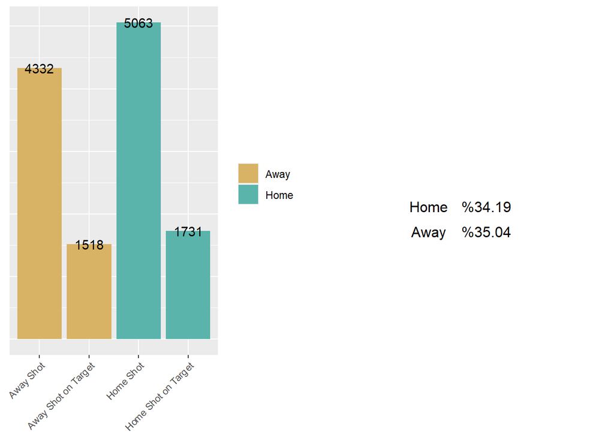

## Most Played Game Hours

### Table

| Time | Game Played |
| --- | --- |
| 15:00:00 | 123 |
| 14:00:00 | 36 |
| 17:30:00 | 35 |

### Code

```r
data %>%
  group_by(Time) %>%
  tally(sort = T) %>%
  top_n(3) %>%
  kable(col.names = c("Time","Game Played"),digits = 2,"html",row.names = FALSE) %>%
  kable_styling(font_size = 20,bootstrap_options = c("striped","hover"))
```

| Time | Game Played |
| --- | --- |
| 15:00:00 | 123 |
| 14:00:00 | 36 |
| 17:30:00 | 35 |

## Full Time Results

Home team always has the advantage since they have more fans in the stadium.

### Table

| Team | Wins |
| --- | --- |
| Home | 172 |
| Away | 116 |
| Draw | 92 |

### Table Code

```r
data %>%
  mutate(FTR = as_factor(FTR)) %>%
  mutate(FTR = recode_factor(FTR,A = "Away", H = "Home", D = "Draw")) %>%
  select(FTR) %>%
  count() %>%
  arrange(desc(freq)) %>%
  kable(col.names = c("Team","Wins"),"html",row.names = FALSE) %>%
  kable_styling(font_size = 20,bootstrap_options = c("striped","hover"))
```

| Team | Wins |
| --- | --- |
| Home | 172 |
| Away | 116 |
| Draw | 92 |

### Plot

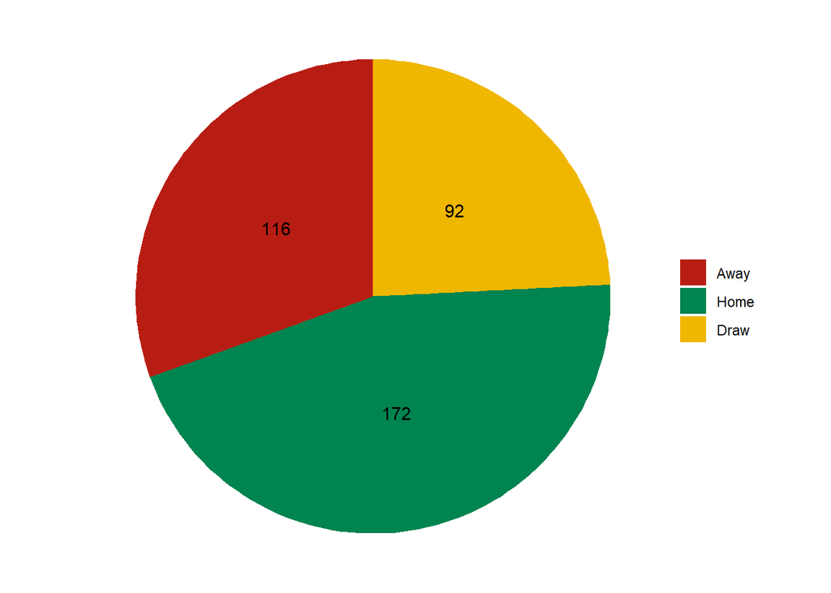

### Plot Code

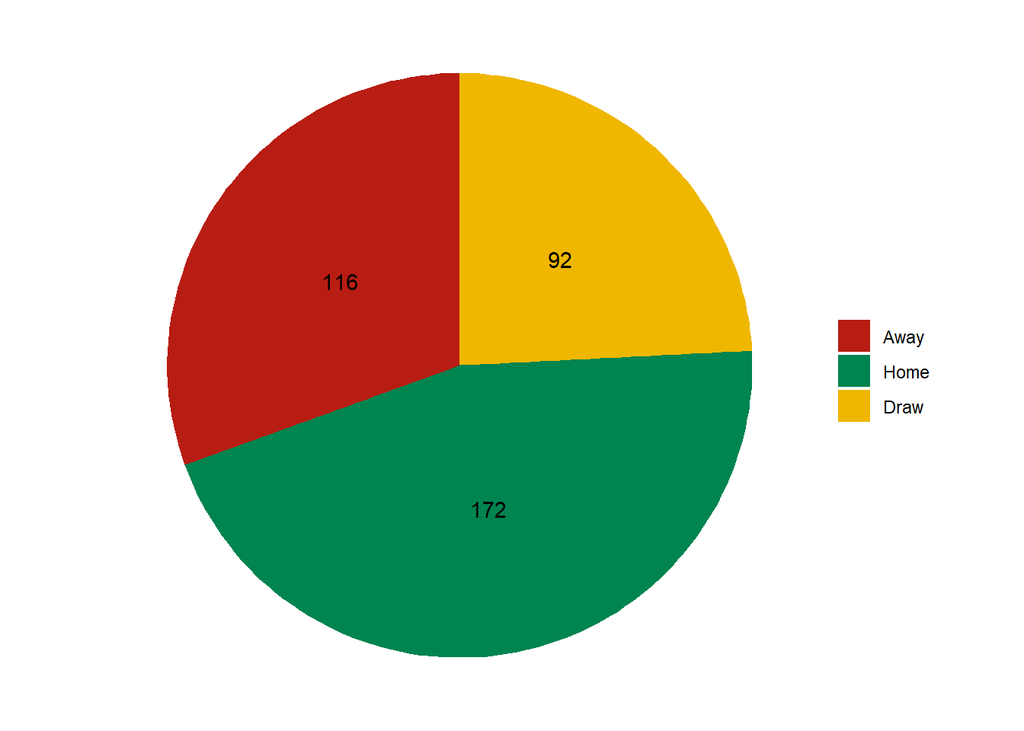

```r
data %>%
  mutate(FTR = as_factor(FTR)) %>%
  mutate(FTR = recode_factor(FTR,A = "Away", H = "Home", D = "Draw")) %>%
  select(FTR) %>%
  count() %>%
  ggplot(aes(x="", y=freq, fill=FTR)) +
  geom_bar(stat = "identity", width=1) +
  coord_polar(theta = "y", start = 0) +
  scale_fill_manual(values=c("#B81D13", "#008450","#EFB700")) +
  geom_text(aes(label = freq),position = position_stack(vjust = 0.5)) +
  theme_void() +
  labs(fill = NULL)
```

## Games with most goals

### Table

| Date | HomeTeam | AwayTeam | FTHG | FTAG |
| --- | --- | --- | --- | --- |
| 25/10/2019 | Southampton | Leicester | 0 | 9 |
| 21/09/2019 | Man City | Watford | 8 | 0 |
| 22/07/2020 | Liverpool | Chelsea | 5 | 3 |

### Code

```r
data %>%
  select(Date,HomeTeam,AwayTeam,FTHG,FTAG) %>%
  mutate(TG = rowSums(select_(.,"FTHG","FTAG"))) %>%
  arrange(desc(TG)) %>%
  head(3) %>%
  select(-TG)%>%
  kable(digits = 2,"html",row.names = FALSE) %>%
  kable_styling(font_size = 20,bootstrap_options = c("striped","hover"))
```

| Date | HomeTeam | AwayTeam | FTHG | FTAG |
| --- | --- | --- | --- | --- |
| 25/10/2019 | Southampton | Leicester | 0 | 9 |
| 21/09/2019 | Man City | Watford | 8 | 0 |
| 22/07/2020 | Liverpool | Chelsea | 5 | 3 |

## Average Odds

### Table

| Bet Platform | Average of Total odds |
| --- | --- |
| WilliamHill | 18.10 |
| Pinnacle | 12.43 |
| Bet365 | 11.96 |
| BetWin | 11.95 |
| Interwetten | 11.75 |
| VCBet | 7.34 |

### Code

```r
data %>%
  mutate(B365s = rowSums(.[grep("B365",names(.))]),
         BWs = rowSums(.[grep("BW",names(.))]),
         IWs = rowSums(.[grep("IW",names(.))]),
         PSs = rowSums(.[grep("PS",names(.))]),
         WHs = rowSums(.[grep("WH",names(.))]),
         VCs = rowSums(.[grep("VC",names(.))])) %>%
  summarise(Bet365 = mean(B365s),
            BetWin = mean(BWs),
            Interwetten = mean(IWs),
            Pinnacle = mean(PSs),
            WilliamHill = mean(WHs),
            VCBet = mean(VCs))%>%
  pivot_longer(everything()) %>%
  arrange(desc(value)) %>%
  kable(digits = 2,"html",row.names = FALSE, col.names = c("Bet Platform","Average of Total odds")) %>%
  kable_styling(font_size = 20,bootstrap_options = c("striped","hover"))
```

| Bet Platform | Average of Total odds |
| --- | --- |
| WilliamHill | 18.10 |
| Pinnacle | 12.43 |
| Bet365 | 11.96 |
| BetWin | 11.95 |
| Interwetten | 11.75 |
| VCBet | 7.34 |

## Mean of Cards

### Table

| Type of Card | Average of Card per game |
| --- | --- |
| RedCard | 0.12 |
| YellowCard | 3.35 |

### Code

```r
data %>%
  mutate(YellowCards = rowSums(select_(.,"HY","AY")),
         RedCards = rowSums(select_(.,"HR","AR"))) %>%
  summarise(RedCard = mean(RedCards) ,
            YellowCard = mean(YellowCards )) %>%
  pivot_longer(everything()) %>%
  kable(digits = 2,"html", row.names = FALSE, col.names = c("Type of Card","Average of Card per game")) %>%
  kable_styling(font_size = 20,bootstrap_options = c("striped","hover")) %>%
  row_spec(1,background = "#FF0000",color = "black") %>%
  row_spec(2,background = "yellow",color = "black")
```

| Type of Card | Average of Card per game |
| --- | --- |
| RedCard | 0.12 |
| YellowCard | 3.35 |

## Top 5 teams that shoot the ball most

### Table

| Team | HomeShots | AwayShots | TotalShots |
| --- | --- | --- | --- |
| Man City | 394 | 351 | 745 |
| Chelsea | 332 | 293 | 625 |
| Liverpool | 314 | 276 | 590 |
| Man United | 299 | 244 | 543 |
| Leicester | 262 | 275 | 537 |

### Code

```r
HomeShot <- data %>%
                pivot_longer(cols = HS) %>%
                group_by(HomeTeam) %>%
                summarise_at(vars(value),list(HomeShots=sum)) %>%
                setNames(c("Team","HomeShots"))


AwayShot <- data %>%
                pivot_longer(cols = AS) %>%
                group_by(AwayTeam) %>%
                summarise_at(vars(value),list(AwayShots = sum)) %>%
                setNames(c("Team","AwayShots"))

TotalShot <- merge(HomeShot,AwayShot, by = "Team")

TotalShot %>%
  mutate(TotalShots = rowSums(select_(.,"HomeShots","AwayShots"))) %>%
  arrange(desc(TotalShots)) %>%
  head(5) %>%
  kable(digits = 2,"html",row.names = FALSE) %>%
  kable_styling(font_size = 20,bootstrap_options = c("striped","hover"))
```

| Team | HomeShots | AwayShots | TotalShots |
| --- | --- | --- | --- |
| Man City | 394 | 351 | 745 |
| Chelsea | 332 | 293 | 625 |
| Liverpool | 314 | 276 | 590 |
| Man United | 299 | 244 | 543 |
| Leicester | 262 | 275 | 537 |

## Top 5 teams that commited fouls

### Table

[output not shown]

### Code

```r
HomeOff <- data %>%
                pivot_longer(cols = HF) %>%
                group_by(HomeTeam) %>%
                summarise_at(vars(value),list(HomeOffs = sum))%>%
                setNames(c("Team","HomeOffs"))


AwayOff <- data %>%
                pivot_longer(cols = AF) %>%
                group_by(AwayTeam) %>%
                summarise_at(vars(value),list(AwayOffs = sum)) %>%
                setNames(c("Team","AwayOffs"))

TotalOff <- merge(HomeOff,AwayOff, by = "Team")

TotalOff %>%
  mutate(TotalOffs = rowSums(select_(.,"HomeOffs","AwayOffs"))) %>%
  arrange(desc(TotalOffs)) %>%
  head(5) %>%
  kable(digits = 2,"html",row.names = FALSE) %>%
  kable_styling(font_size = 20,bootstrap_options = c("striped","hover"))
```

| Team | HomeOffs | AwayOffs | TotalOffs |
| --- | --- | --- | --- |
| Watford | 258 | 226 | 484 |
| Everton | 220 | 252 | 472 |
| Aston Villa | 231 | 220 | 451 |
| Southampton | 198 | 252 | 450 |
| Man United | 223 | 210 | 433 |

## Top 5 teams that awarded with corners

### Table

| Team | HomeCors | AwayCors | TotalCors |
| --- | --- | --- | --- |
| Man City | 157 | 141 | 298 |
| Liverpool | 144 | 114 | 258 |
| Chelsea | 137 | 110 | 247 |
| Arsenal | 128 | 103 | 231 |
| Leicester | 118 | 104 | 222 |

### Code

```r
HomeCor <- data %>%
                pivot_longer(cols = HC) %>%
                group_by(HomeTeam) %>%
                summarise_at(vars(value),list(HomeCors = sum)) %>%
                setNames(c("Team","HomeCors"))


AwayCor <- data %>%
                pivot_longer(cols = AC) %>%
                group_by(AwayTeam) %>%
                summarise_at(vars(value),list(AwayCors = sum)) %>%
                setNames(c("Team","AwayCors"))

TotalCor <- merge(HomeCor,AwayCor, by = "Team")

TotalCor %>%
  mutate(TotalCors = rowSums(select_(.,"HomeCors","AwayCors"))) %>%
  arrange(desc(TotalCors)) %>%
  head(5) %>%
  kable(digits = 2,"html",row.names = FALSE) %>%
  kable_styling(font_size = 20,bootstrap_options = c("striped","hover"))
```

| Team | HomeCors | AwayCors | TotalCors |
| --- | --- | --- | --- |
| Man City | 157 | 141 | 298 |
| Liverpool | 144 | 114 | 258 |
| Chelsea | 137 | 110 | 247 |
| Arsenal | 128 | 103 | 231 |
| Leicester | 118 | 104 | 222 |

## Top 5 teams that conceded most goals at home

### Table

| HomeTeam | AwayTeamGoal |
| --- | --- |
| Norwich | 37 |
| Southampton | 35 |
| West Ham | 33 |
| Aston Villa | 30 |
| Bournemouth | 30 |

### Code

```r
data %>%
  pivot_longer(cols = FTAG) %>%
  group_by(HomeTeam) %>%
  summarise_at(vars(value),list(AwayTeamGoal = sum)) %>%
  arrange(desc(AwayTeamGoal)) %>%
  head(5) %>%
  kable("html",row.names = FALSE) %>%
  kable_styling(font_size = 20,bootstrap_options = c("striped","hover"))
```

| HomeTeam | AwayTeamGoal |
| --- | --- |
| Norwich | 37 |
| Southampton | 35 |
| West Ham | 33 |
| Aston Villa | 30 |
| Bournemouth | 30 |

## Top 5 teams that conceded most goals at home in the first half

### Table

| HomeTeam | AwayTeamGoal |
| --- | --- |
| Southampton | 19 |
| Aston Villa | 16 |
| Bournemouth | 16 |
| Arsenal | 14 |
| Norwich | 13 |

### Code

```r
data %>%
  pivot_longer(cols = HTAG) %>%
  group_by(HomeTeam) %>%
  summarise_at(vars(value),list(AwayTeamGoal = sum)) %>%
  arrange(desc(AwayTeamGoal)) %>%
  head(5) %>%
  kable("html",row.names = FALSE) %>%
  kable_styling(font_size = 20,bootstrap_options = c("striped","hover"))
```

| HomeTeam | AwayTeamGoal |
| --- | --- |
| Southampton | 19 |
| Aston Villa | 16 |
| Bournemouth | 16 |
| Arsenal | 14 |
| Norwich | 13 |

## Top 5 teams that scored most goals at home

### Table

| HomeTeam | HomeTeamGoal |
| --- | --- |
| Man City | 57 |
| Liverpool | 52 |
| Man United | 40 |
| Arsenal | 36 |
| Tottenham | 36 |

### Code

```r
data %>%
  pivot_longer(cols = FTHG) %>%
  group_by(HomeTeam) %>%
  summarise_at(vars(value),list(HomeTeamGoal = sum)) %>%
  arrange(desc(HomeTeamGoal)) %>%
  head(5) %>%
  kable("html",row.names = FALSE) %>%
  kable_styling(font_size = 20,bootstrap_options = c("striped","hover"))
```

| HomeTeam | HomeTeamGoal |
| --- | --- |
| Man City | 57 |
| Liverpool | 52 |
| Man United | 40 |
| Arsenal | 36 |
| Tottenham | 36 |

## Top 5 teams that scored most goals at home in the first half

### Table

| HomeTeam | HomeTeamGoal |
| --- | --- |
| Liverpool | 29 |
| Man City | 27 |
| Arsenal | 21 |
| Man United | 21 |
| Tottenham | 19 |

### Code

```r
data %>%
  pivot_longer(cols = HTHG) %>%
  group_by(HomeTeam) %>%
  summarise_at(vars(value),list(HomeTeamGoal = sum)) %>%
  arrange(desc(HomeTeamGoal)) %>%
  head(5) %>%
  kable("html",row.names = FALSE) %>%
  kable_styling(font_size = 20,bootstrap_options = c("striped","hover"))
```

| HomeTeam | HomeTeamGoal |
| --- | --- |
| Liverpool | 29 |
| Man City | 27 |
| Arsenal | 21 |
| Man United | 21 |
| Tottenham | 19 |

## Top 5 teams that conceded most goals at away

### Table

| AwayTeam | HomeTeamGoal |
| --- | --- |
| Chelsea | 38 |
| Norwich | 38 |
| Aston Villa | 37 |
| Newcastle | 37 |
| Watford | 37 |

### Code

```r
data %>%
  pivot_longer(cols = FTHG) %>%
  group_by(AwayTeam) %>%
  summarise_at(vars(value),list(HomeTeamGoal = sum)) %>%
  arrange(desc(HomeTeamGoal)) %>%
  head(5) %>%
  kable("html",row.names = FALSE) %>%
  kable_styling(font_size = 20,bootstrap_options = c("striped","hover"))
```

| AwayTeam | HomeTeamGoal |
| --- | --- |
| Chelsea | 38 |
| Norwich | 38 |
| Aston Villa | 37 |
| Newcastle | 37 |
| Watford | 37 |

## Top 5 teams that conceded most goals at away in the first half

### Table

| AwayTeam | HomeTeamGoal |
| --- | --- |
| Norwich | 22 |
| Watford | 20 |
| Bournemouth | 19 |
| Burnley | 16 |
| Chelsea | 16 |

### Code

```r
data %>%
  pivot_longer(cols = HTHG) %>%
  group_by(AwayTeam) %>%
  summarise_at(vars(value),list(HomeTeamGoal = sum)) %>%
  arrange(desc(HomeTeamGoal)) %>%
  head(5) %>%
  kable("html",row.names = FALSE) %>%
  kable_styling(font_size = 20,bootstrap_options = c("striped","hover"))
```

| AwayTeam | HomeTeamGoal |
| --- | --- |
| Norwich | 22 |
| Watford | 20 |
| Bournemouth | 19 |
| Burnley | 16 |
| Chelsea | 16 |

## Top 5 teams that scored most goals at away

### Table

| AwayTeam | AwayTeamGoal |
| --- | --- |
| Man City | 45 |
| Chelsea | 39 |
| Liverpool | 33 |
| Leicester | 32 |
| Southampton | 30 |

### Code

```r
data %>%
  pivot_longer(cols = FTAG) %>%
  group_by(AwayTeam) %>%
  summarise_at(vars(value),list(AwayTeamGoal = sum)) %>%
  arrange(desc(AwayTeamGoal)) %>%
  head(5) %>%
  kable("html",row.names = FALSE) %>%
  kable_styling(font_size = 20,bootstrap_options = c("striped","hover"))
```

| AwayTeam | AwayTeamGoal |
| --- | --- |
| Man City | 45 |
| Chelsea | 39 |
| Liverpool | 33 |
| Leicester | 32 |
| Southampton | 30 |

## Top 5 teams that scored most goals at away in the first half

### Table

| AwayTeam | AwayTeamGoal |
| --- | --- |
| Man City | 21 |
| Chelsea | 20 |
| Liverpool | 15 |
| Leicester | 14 |
| Man United | 14 |

### Code

```r
data %>%
  pivot_longer(cols = HTAG) %>%
  group_by(AwayTeam) %>%
  summarise_at(vars(value),list(AwayTeamGoal = sum)) %>%
  arrange(desc(AwayTeamGoal)) %>%
  head(5) %>%
  kable("html",row.names = FALSE) %>%
  kable_styling(font_size = 20,bootstrap_options = c("striped","hover"))
```

| AwayTeam | AwayTeamGoal |
| --- | --- |
| Man City | 21 |
| Chelsea | 20 |
| Liverpool | 15 |
| Leicester | 14 |
| Man United | 14 |